# Boosting ALS Data Set

Shan Chen

4/27/2020

```r
als.df <- read.table("http://web.stanford.edu/~hastie/CASI_files/DATA/ALS.txt",header=TRUE)
dim(als.df)
```

```
## [1] 1822  371
```

```r
numCol <- ncol(als.df)
```

```r
names(als.df)
```

```
##   [1] "testset"
##   [2] "dFRS"
##   [3] "Onset.Delta"
##   [4] "Symptom.Speech"
##   [5] "Symptom.WEAKNESS"
##   [6] "Symptom.OTHER"
##   [7] "Symptom.Swallowing"
##   [8] "Symptom.GAIT_CHANGES"
##   [9] "Symptom.Atrophy"
##  [10] "Symptom.Cramps"
##  [11] "Symptom.Fasciculations"
##  [12] "Symptom.SENSORY_CHANGES"
##  [13] "Symptom.Stiffness"
##  [14] "Symptom.."
##  [15] "Site.of.Onset.Onset..Bulbar"
```

[output cut: 356 more lines]

Drop the first column

```r
als.df <- als.df %>%
  select(-testset)
```

```r
with(als.df,summary(dFRS))
```

```
##    Min. 1st Qu.  Median    Mean 3rd Qu.    Max.
## -3.1033 -1.0260 -0.5916 -0.6855 -0.2497  1.2078
```

And the libraries….

```r
library(tidyverse)
library(tree)
library(glmnet)
library(randomForest)
library(gbm)
```

#Models

Let’s build all the models. It’s nice that each as cross-validated or bootstrapped estimates of the error rates.

## Penalized Regression

Build the data matrices.

```r
als.x <- data.matrix(als.df[,-1])
als.y <- data.matrix(als.df[,1])
```

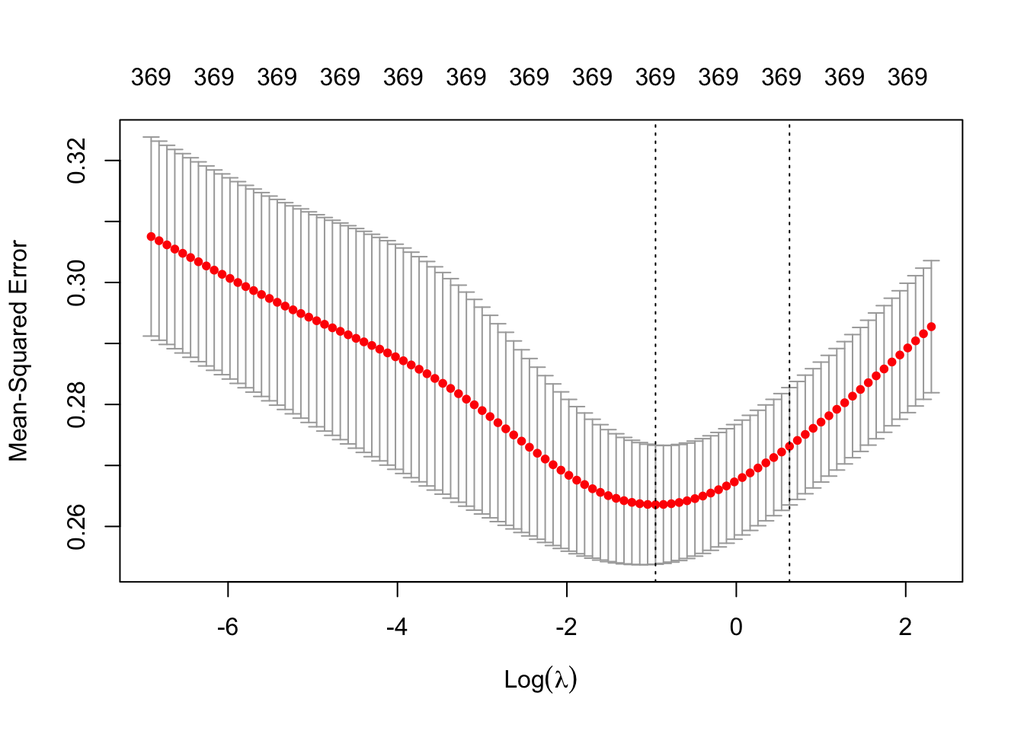

```r
lambda.grid <- 10^seq(-3,1,length=100)
mod.ridge.cv <- cv.glmnet(als.x,als.y,
                          lambda=lambda.grid,
                          alpha=0)
plot(mod.ridge.cv)
```

Pull of the One SE lambda value.

```r
lambda.opt <- mod.ridge.cv$lambda.1se
mse.ridge <- with(mod.ridge.cv,cvm[lambda == lambda.opt])
```

Same for Lasso

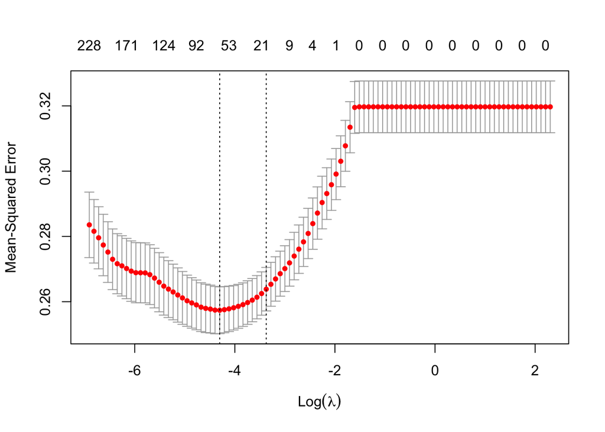

```r
mod.lasso.cv <- cv.glmnet(als.x,als.y,
                          lambda=lambda.grid,
                          alpha=1)
plot(mod.lasso.cv)
```

```r
lambda.opt <- mod.ridge.cv$lambda.1se
mse.lasso <- with(mod.lasso.cv,cvm[lambda == lambda.opt])
```

How are we doing?

```r
c(mse.ridge,mse.lasso)
```

```
## [1] 0.2731422 0.3197143
```

Interesting…ridge seems to be winning

# Bagged Trees

Now let’s try Bagging and Random Forests.

These take a minute to compute, using fours cores to accelerate

```r
numCol <- ncol(als.df)
mod.bag <- randomForest(dFRS ~ .,
                        data=als.df,
                        ntree=500,
                        mtry=numCol-1,
                        n.cores = 4)
```

```r
mod.bag
```

```
##
## Call:
##  randomForest(formula = dFRS ~ ., data = als.df, ntree = 500,      mtry = numCol - 1, n.cores = 4)
##                Type of random forest: regression
##                      Number of trees: 500
## No. of variables tried at each split: 369
##
##           Mean of squared residuals: 0.2525497
##                     % Var explained: 20.95
```

```r
(mse.bag <- mod.bag$mse[500])
```

```
## [1] 0.2525497
```

Now a random forest. This takes some time too (but not as much time since there are fewer predictors in play at each step).

```r
mod.rf <- randomForest(dFRS ~ .,
                       data=als.df,
                       ntree=500,
                       mtry=(numCol-1)/3)
```

```r
mod.rf
```

```
##
## Call:
##  randomForest(formula = dFRS ~ ., data = als.df, ntree = 500,      mtry = (numCol - 1)/3)
##                Type of random forest: regression
##                      Number of trees: 500
## No. of variables tried at each split: 123
##
##           Mean of squared residuals: 0.2516668
##                     % Var explained: 21.22
```

```r
(mse.rf <- mod.rf$mse[500])
```

```
## [1] 0.2516668
```

# Conclusion for the old methods:

Which one is the best?

```r
c(mse.ridge, mse.lasso, mse.bag,mse.rf)
```

```
## [1] 0.2731422 0.3197143 0.2525497 0.2516668
```

We can see that: Looks as if the edge goes to the Trees: Bagging and Random Forest seem to work equally well, beating out the penalized regresssion algorithms.

#Now for our Boosting model:

```r
n <- nrow(als.df)
numFolds=5
folds <- sample(1:numFolds,n,rep=T)
errs <- numeric(numFolds)
for(fold in 1:numFolds){
  train.df.cv <- als.df[folds != fold,]
  test.df.cv <- als.df[folds == fold,]
}
numTrees <- 1000
theShrinkage <- 0.1
theDepth <- 2
mod.gbm <- gbm(dFRS ~.,
               data=train.df.cv,
               distribution="gaussian", ## for regression
               n.trees=numTrees,
               shrinkage=theShrinkage,
               interaction.depth = theDepth,
               n.cores = 4)
```

```r
numTreesPred <- 500
prob.gbm <- predict(mod.gbm,
                    newdata=test.df.cv,
                    n.trees=100,type="response")
pred.gbm <- predict(mod.gbm,
                    newdata=test.df.cv,
                    n.trees=numTreesPred)
```

```r
mod.gbm.cv <- gbm(dFRS ~.,
                  data=train.df.cv,
                  distribution="gaussian", ## for regression
                  n.trees=numTrees,
                  shrinkage=theShrinkage,
                  interaction.depth = theDepth,
                  n.cores = 4)
gbm.perf(mod.gbm.cv)
```

```
## OOB generally underestimates the optimal number of iterations although predictive performance is reasonably competitive. Using cv_folds>1 when calling gbm usually results in improved predictive performance.
```

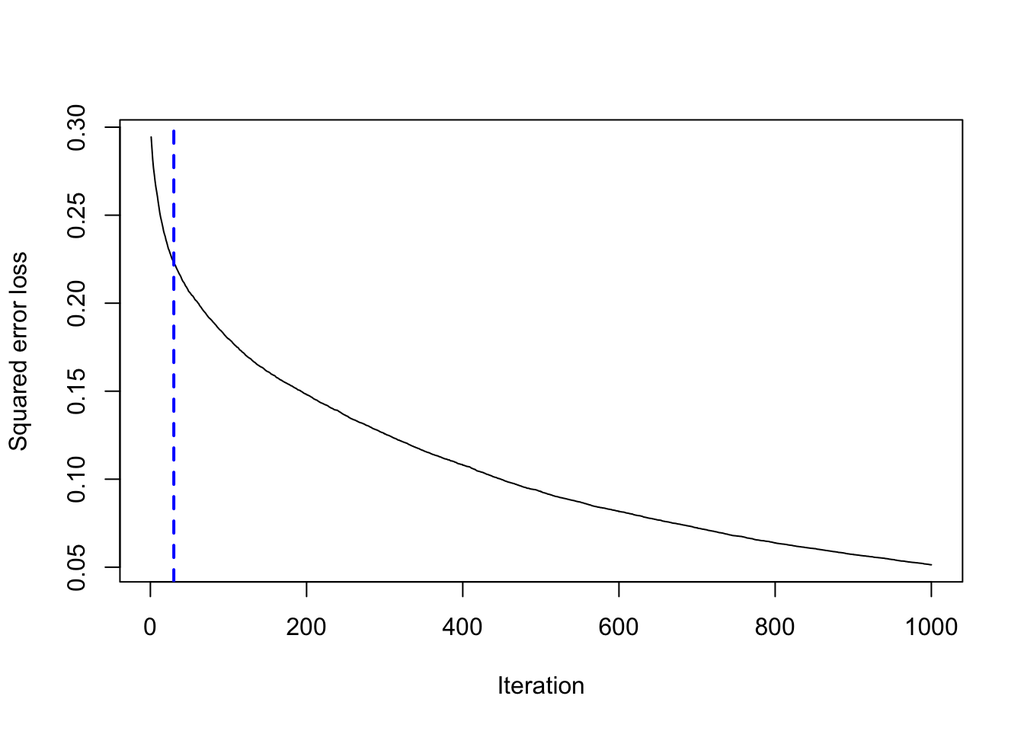

```
## [1] 30
## attr(,"smoother")
## Call:
## loess(formula = object$oobag.improve ~ x, enp.target = min(max(4,
##     length(x)/10), 50))
##
## Number of Observations: 1000
## Equivalent Number of Parameters: 40
## Residual Standard Error: 0.000183
```

```r
theShrinkage <- 0.05
mod.gbm.cv <- gbm(dFRS ~.,
                  data=als.df,
                  distribution="gaussian", ## for regression
                  n.trees=numTrees,
                  shrinkage=theShrinkage,
                  interaction.depth = theDepth,
                  n.cores = 4)
(numTreesOpt <- gbm.perf(mod.gbm.cv))
```

```
## OOB generally underestimates the optimal number of iterations although predictive performance is reasonably competitive. Using cv_folds>1 when calling gbm usually results in improved predictive performance.
```

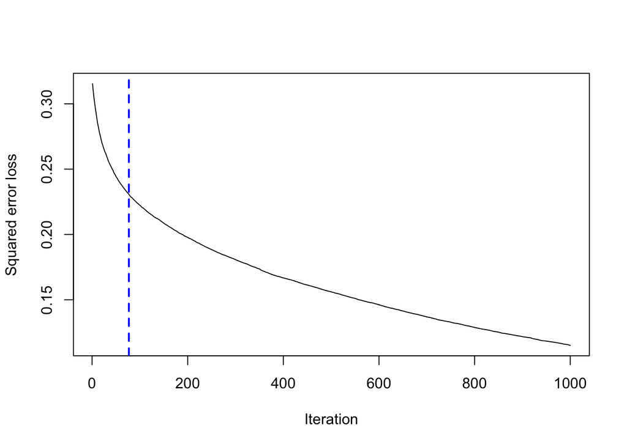

```
## [1] 77
## attr(,"smoother")
## Call:
## loess(formula = object$oobag.improve ~ x, enp.target = min(max(4,
##     length(x)/10), 50))
##
## Number of Observations: 1000
## Equivalent Number of Parameters: 40
## Residual Standard Error: 9.99e-05
```

#CV GBM func

```r
cvGBM <- function(data.df,
                  theShrinkage,
                  theDepth,
                  numTreesPred,
                  numFolds=5){
  N <- nrow(data.df)
  folds <- sample(1:numFolds,N,rep=T)
  errs <- numeric(numFolds)
  fold <- 1
  for(fold in 1:numFolds){
    train.df.cv <- als.df[folds != fold,]
    test.df.cv <- als.df[folds == fold,]
    mod.gbm <- gbm(dFRS ~ . ,
                   data=train.df.cv,
                   distribution="gaussian",
                   interaction.depth = theDepth,
                   shrinkage=theShrinkage,
                   n.minobsinnode=10,
                   n.trees=numTrees)
    pred.gbm <- predict(mod.gbm,
                        newdata=test.df.cv,
                        n.trees=numTreesPred)
    errs[fold] <- with(test.df.cv,mean((dFRS-pred.gbm)^2))
  }
  mean(errs)
}
```

#See how this work with opt tree number

```r
cvGBM(als.df,theShrinkage, theDepth,numTreesOpt)
```

```
## [1] 0.2558719
```

Now lets focus on the other two factors: shrink.vals <- 10^c(-2.0, -1.0, 0.0) depth.vals <- c(1,2,4,6) cv.grid <- expand.grid(shrink=shrink.vals, depth=depth.vals) cv.vals <- apply(cv.grid,1,function(row) { print(row) cvGBM(als.df,row[1],row[2],numTreesOpt) }) (bestVals <- cv.grid[id,]) Takes too long to run, so i will just used the saved data from last run here:

```r
shrinkOpt <- 0.1
depthOpt <- 4
```

Then lets see our optimal mse value for boosting

```r
(mse.boosting <- cvGBM(als.df,shrinkOpt, depthOpt, numTreesOpt))
```

```
## [1] 0.2526844
```

```r
err.boosting <- mse.boosting
c(mse.boosting, mse.ridge, mse.lasso, mse.bag,mse.rf)
```

```
## [1] 0.2526844 0.2731422 0.3197143 0.2525497 0.2516668
```

```r
numPreds <- ncol(als.df)-1
mod.gbm.cv <- gbm(dFRS ~ .,
                  data=als.df,
                  distribution="gaussian", ## for regression
                  n.trees=numTreesOpt,
                  shrinkage=shrinkOpt,
                  interaction.depth = depthOpt,
                  cv.folds = 5,
                  n.minobsinnode=10,
                  n.cores = 4)
numTreesOpt <- gbm.perf(mod.gbm.cv,method="cv")
```

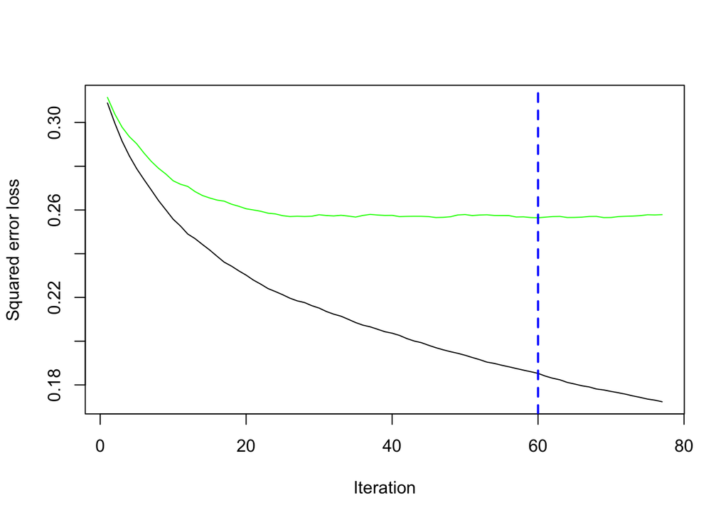

```r
mod.gbm <- gbm(dFRS ~ .,
               data=als.df,
               distribution="gaussian", ## for regression
               n.trees=numTreesOpt,
               shrinkage=theShrinkage,
               interaction.depth = theDepth
)
```

[figure not shown]

[output not shown]

[output cut: 685 more lines]

[output not shown]

```r
summary(mod.gbm)
```

```r
influence.sum <- summary(mod.gbm)
```

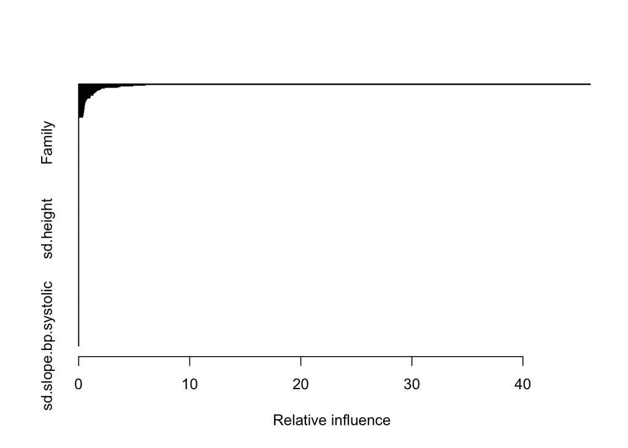

```r
influence.df <- data.frame(var=influence.sum[,1],
                           influence=influence.sum[,2])
##Checking...should be 100%
with(influence.df,sum(influence))
```

```
## [1] 100
```

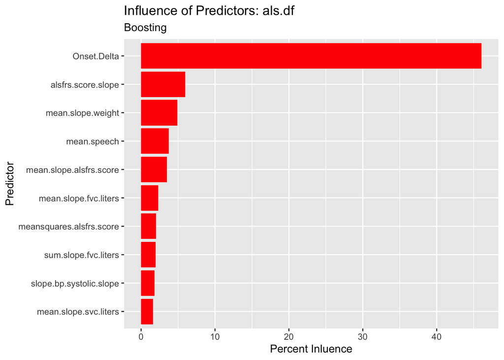

```r
influence.df <- influence.df %>%
  mutate(var=fct_reorder(var,desc(-influence)))
influence.df[1:10,]%>%
  ggplot()+
  geom_bar(aes(var,influence),
           stat="identity",
           fill="red")+
  coord_flip()+
  labs(title="Influence of Predictors: als.df",
       subtitle="Boosting",
       x="Predictor",
       y="Percent Inluence")
```